# The single cell proteomics data package

### 3.1.4 Quality control

Let’s check how the normalization, imputation, and batch correction affects the data.

#### 3.1.4.1 Normalization

First, let’s look at the mean and standard deviation distributions before the normalization step:

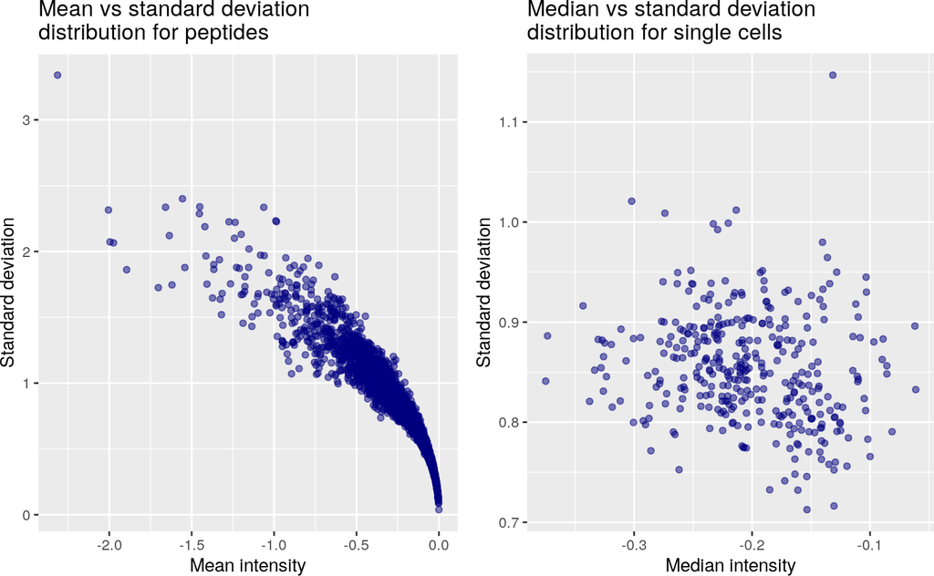

Now, after the data normalization:

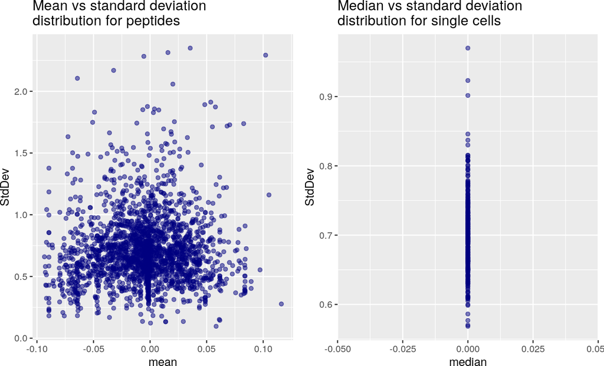

#### 3.1.4.2 Imputation

To asses imputation, we can have a look at single cell data as a heatmap. Before imputation (after normalization), the data looks like this:

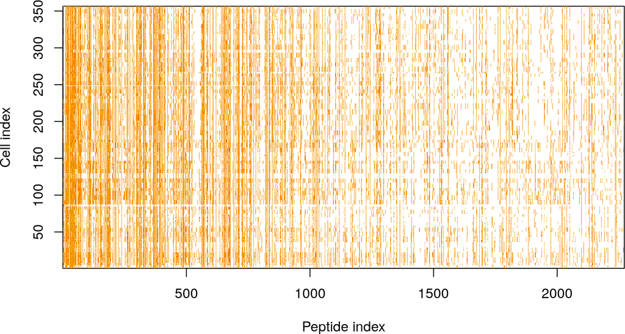

After imputation:

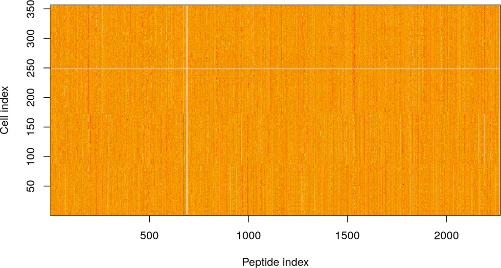

Since the distance measure used for the KNN is Euclidean distance, it is interesting to look at how the similarity between cells is affected by the imputation:

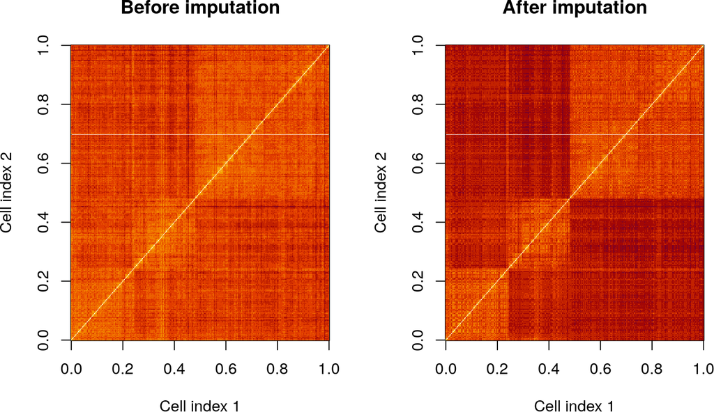

Checking the coefficient of variation (sd/mean)

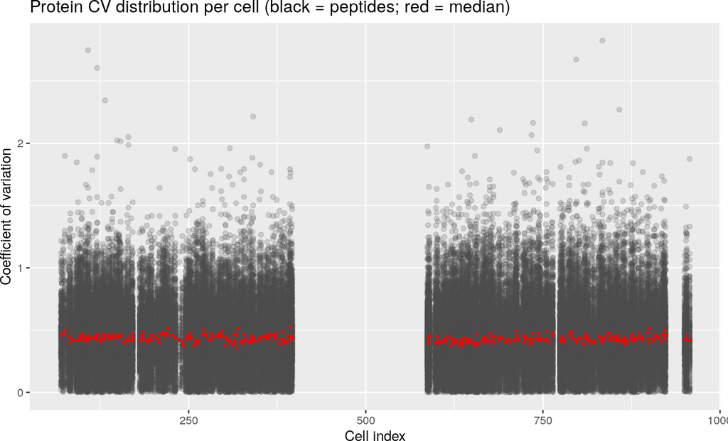